Saltar al contenido principal

# Actividad 9: group_by, nest y map

Respiración microbiana por sitio (utilizando mis datos simulados)

Autor/a

Mariana dos Santos Moreno

> Los datos fueron simulados con `scripts/01_simular_datos.R`, así que no son resultados reales.

En mi tesis, medimos la respiración microbiana (RM) de cada sitio a 20, 30 y 40°C. Supongamos que queremos saber qué tan sensible a la temperatura es la respiración en cada sitio, es decir, su Q<sub>10</sub> (cuántas veces aumenta la respiración con 10°C más). Para eso tendríamos que ajustar el mismo modelo 120 veces, una por sitio, lo que es muy bueno para `nest()` y `map()`.

```r
library(tidyverse)
library(broom)

sitios <- read_csv("../datos/sitios.csv")
resp   <- read_csv("../datos/suelo_respiracion.csv")
```

## 1. Los datos

Utilizamos solo la humedad de 70% CRA para comparar todos los sitios en la misma condición, y unimos los datos de cada sitio (tipo de cobertura y quintil de temperatura).

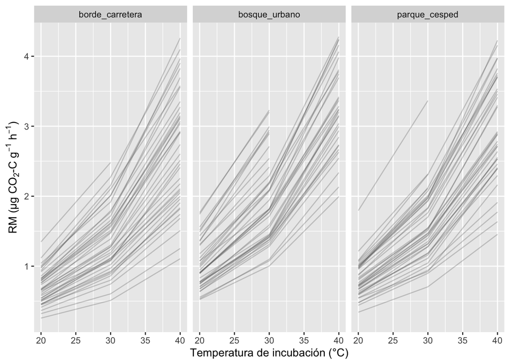

```r
resp70 <- resp |>
  filter(humedad_cra_pct == 70) |>
  left_join(sitios, by = "sitio_id")

ggplot(resp70, aes(temp_incubacion_c, rm_ug_co2c_g_h, group = sitio_id)) +
  geom_line(stat = "summary", fun = mean, alpha = 0.3, colour = "grey40") +
  facet_wrap(~ tipo_cobertura) +
  labs(x = "Temperatura de incubación (°C)",
       y = expression("RM (µg CO"[2]*"-C g"^-1*" h"^-1*")"))
```

En el gráfico, cada línea es un sitio y la respiración aumenta con la temperatura en todos, pero no al mismo ritmo.

## 2. Agrupar con `nest()`

El sitio es la unidad en la que queremos un Q<sub>10</sub>. Así como en el ejemplo de gapminder sobre los continentes, agregamos la cobertura para luego buscar patrones entre grupos. Cada sitio queda con su propia tabla de datos dentro de la columna `data`.

```r
by_sitio <- resp70 |>
  nest(.by = c(tipo_cobertura, quintil_icu, sitio_id))
by_sitio
```

```
# A tibble: 120 × 4
   tipo_cobertura  quintil_icu sitio_id data
   <chr>           <chr>       <chr>    <list>
 1 bosque_urbano   Q4          S001     <tibble [9 × 11]>
 2 bosque_urbano   Q5          S002     <tibble [9 × 11]>
 3 parque_cesped   Q5          S003     <tibble [9 × 11]>
 4 borde_carretera Q2          S004     <tibble [9 × 11]>
 5 bosque_urbano   Q3          S005     <tibble [9 × 11]>
 6 bosque_urbano   Q3          S006     <tibble [9 × 11]>
 7 bosque_urbano   Q2          S007     <tibble [9 × 11]>
 8 parque_cesped   Q4          S008     <tibble [9 × 11]>
 9 borde_carretera Q2          S009     <tibble [9 × 11]>
10 parque_cesped   Q2          S010     <tibble [9 × 11]>
# ℹ 110 more rows
```

## 3. Un modelo por sitio con `map()`

Está comprobado que la respiración crece de forma exponencial con la temperatura. Si uso el logaritmo de la RM, la relación se vuelve lineal, y el Q<sub>10</sub> sale de la pendiente, p. ej.: Q10 = exp(10 × pendiente).

```r
by_sitio_lm <- by_sitio |>
  mutate(model = map(data, \(x) lm(log(rm_ug_co2c_g_h) ~ temp_incubacion_c,
                                   data = x)))
```

## 4. Extraer resultados con `glance()` y `tidy()`

En ese contexto, `glance()` nos da el ajuste de cada modelo (R<sup>2</sup>) y `tidy()` los coeficientes, de donde calculamos el Q<sub>10</sub>. También contamos cuántas mediciones tiene cada sitio (`n`), porque hay datos faltantes.

```r
models <- by_sitio_lm |>
  mutate(glance = map(model, glance),
         tidy   = map(model, tidy),
         rsq    = map_dbl(glance, "r.squared"),
         q10    = map_dbl(tidy, \(t) exp(10 * t$estimate[2])),
         n      = map_int(data, \(x) sum(!is.na(x$rm_ug_co2c_g_h))))

models |> select(sitio_id, tipo_cobertura, rsq, q10, n)
```

```
# A tibble: 120 × 5
   sitio_id tipo_cobertura    rsq   q10     n
   <chr>    <chr>           <dbl> <dbl> <int>
 1 S001     bosque_urbano   0.985  2.01     6
 2 S002     bosque_urbano   0.969  1.98     9
 3 S003     parque_cesped   0.987  1.89     9
 4 S004     borde_carretera 0.986  2.02     9
 5 S005     bosque_urbano   0.976  1.85     6
 6 S006     bosque_urbano   0.988  1.79     7
 7 S007     bosque_urbano   0.988  1.91     9
 8 S008     parque_cesped   0.981  1.98     9
 9 S009     borde_carretera 0.976  1.96     9
10 S010     parque_cesped   0.995  2.01     9
# ℹ 110 more rows
```

## 5. Existe un patrón en los R<sup><sub>2</sub></sup>?

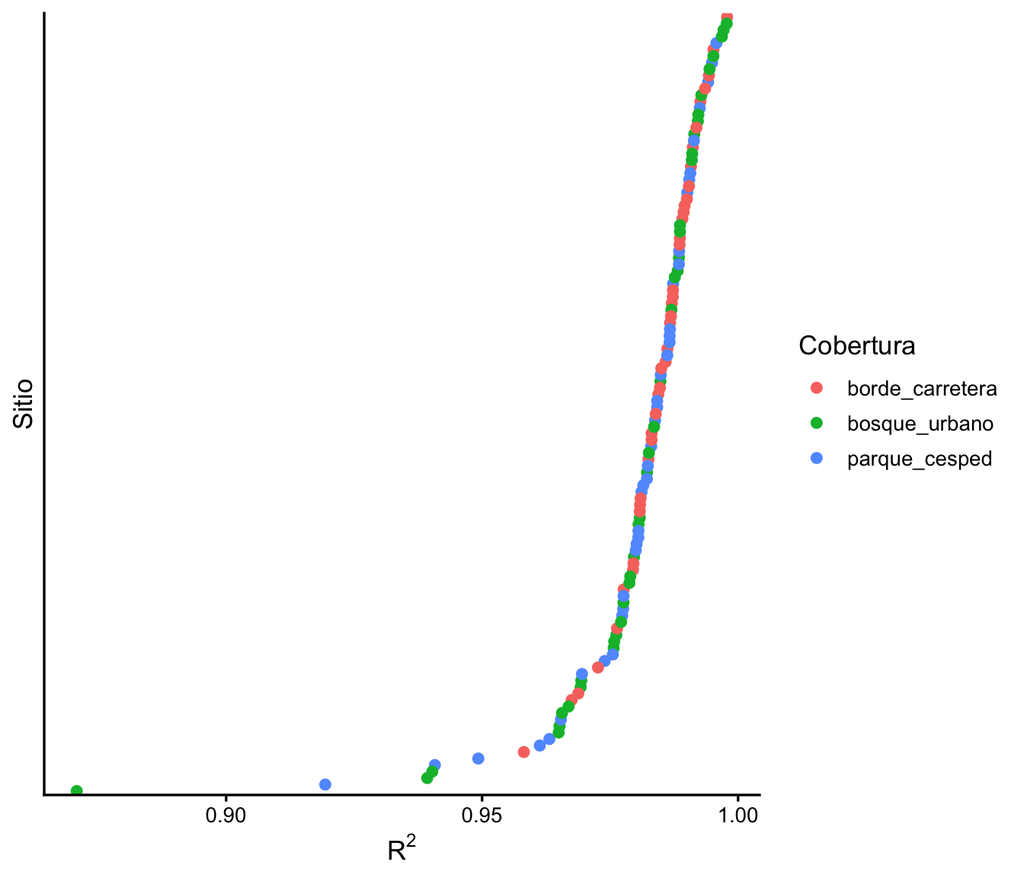

```r
models |>
  ggplot(aes(x = rsq, y = fct_reorder(sitio_id, rsq))) +
  geom_point(aes(colour = tipo_cobertura), size = 2) +
  theme_classic(13) +
  theme(axis.text.y = element_blank(), axis.ticks.y = element_blank()) +
  labs(x = expression(R^2), y = "Sitio", colour = "Cobertura")
```

El modelo ajusta muy bien en casi todos los sitios (R<sup>2</sup> alto), pero algunos quedan por debajo.

## 6. Los 12 sitios con menor R<sup>2</sup>

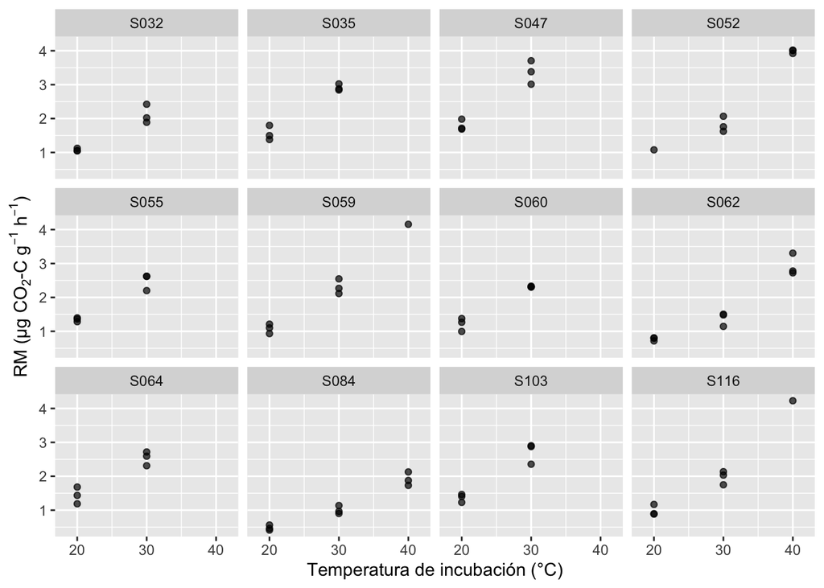

```r
models |>
  slice_min(rsq, n = 12) |>
  select(sitio_id, rsq, n, data) |>
  unnest(data) |>
  ggplot(aes(temp_incubacion_c, rm_ug_co2c_g_h)) +
  geom_point(alpha = 0.7) +
  facet_wrap(vars(sitio_id), nrow = 3) +
  scale_x_continuous(breaks = c(20, 30, 40), limits = c(18, 42)) +
  labs(x = "Temperatura de incubación (°C)",
       y = expression("RM (µg CO"[2]*"-C g"^-1*" h"^-1*")"))
```

```r
models |>
  slice_min(rsq, n = 12) |>
  select(sitio_id, tipo_cobertura, rsq, q10, n)
```

```
# A tibble: 12 × 5
   sitio_id tipo_cobertura    rsq   q10     n
   <chr>    <chr>           <dbl> <dbl> <int>
 1 S064     bosque_urbano   0.871  1.78     6
 2 S060     parque_cesped   0.919  1.93     6
 3 S035     bosque_urbano   0.939  1.88     6
 4 S103     bosque_urbano   0.940  1.98     6
 5 S047     parque_cesped   0.941  1.87     6
 6 S032     parque_cesped   0.949  1.95     6
 7 S055     borde_carretera 0.958  1.84     6
 8 S116     parque_cesped   0.961  2.07     7
 9 S059     parque_cesped   0.963  2.01     7
10 S062     bosque_urbano   0.965  1.95     9
11 S052     bosque_urbano   0.965  1.99     7
12 S084     parque_cesped   0.965  2.00     9
```

Como los datos son simulados con un Q<sub>10</sub> = 2 en todos los sitios, los R<sup>2</sup> solo reflejan los parámetros definidos y no esperamos diferencias entre coberturas o quintiles; lo único que sí muestran es que varios de los sitios con menor R<sup>2</sup> tienen menos de 9 mediciones porque les faltan los valores a 40°C (muestras que saturaron la placa de MicroResp, un dato faltante MNAR), de modo que el ajuste empeora justo en los sitios con mayor respiración y su Q<sub>10</sub> se estima solo con 20 y 30°C, por lo que, con los datos reales, tendremos que repetir esas muestras antes de comparar el Q10 entre sitios y responder la pregunta central, si el Q<sub>10</sub> cambia con la isla de calor.